# Cell type annotation

**Original Authors:** Dario Righelli, Marcel Ramos, Ludwig Geistlinger, Davide Risso  
**Presenting Author:** Davide Risso, Helena Crowell  
**Date:** 24-29 May, 2026

# Setup

```r
library(AUCell)
library(MouseGastrulationData)
library(SingleR)
library(bluster)
library(scater)
library(scran)
```

# Data retrieval

```r
sce <- WTChimeraData(samples = 5, type = "processed")
```

```r
sce
```

```
## class: SingleCellExperiment
## dim: 29453 2411
## metadata(0):
## assays(1): counts
## rownames(29453): ENSMUSG00000051951 ENSMUSG00000089699 ...
##   ENSMUSG00000095742 tomato-td
## rowData names(2): ENSEMBL SYMBOL
## colnames(2411): cell_9769 cell_9770 ... cell_12178 cell_12179
## colData names(11): cell barcode ... doub.density sizeFactor
## reducedDimNames(2): pca.corrected.E7.5 pca.corrected.E8.5
## mainExpName: NULL
## altExpNames(0):
```

To speed up the computations, we subsample the dataset to 1,000 cells.

```r
set.seed(123)
ind <- sample(ncol(sce), 1000)
sce <- sce[,ind]
```

# Preprocessing

```r
sce <- logNormCounts(sce)
sce <- runPCA(sce)
```

# Clustering

Clustering is an unsupervised learning procedure that is used to empirically define groups of cells with similar expression profiles. Its primary purpose is to summarize complex scRNA-seq data into a digestible format for human interpretation. This allows us to describe population heterogeneity in terms of discrete labels that are easily understood, rather than attempting to comprehend the high-dimensional manifold on which the cells truly reside. After annotation based on marker genes, the clusters can be treated as proxies for more abstract biological concepts such as cell types or states.

Popularized by its use in [Seurat](https://cran.r-project.org/web/packages/Seurat/index.html), graph-based clustering is a flexible and scalable technique for clustering large scRNA-seq datasets. We first build a graph where each node is a cell that is connected to its nearest neighbors in the high-dimensional space. Edges are weighted based on the similarity between the cells involved, with higher weight given to cells that are more closely related. We then apply algorithms to identify “communities” of cells that are more connected to cells in the same community than they are to cells of different communities. Each community represents a cluster that we can use for downstream interpretation.

Here, we use the `clusterCells()` function from the scran package to perform graph-based clustering using the [Louvain algorithm](https://doi.org/10.1088/1742-5468/2008/10/P10008) for community detection. All calculations are performed using the top PCs to take advantage of data compression and denoising. This function returns a vector containing cluster assignments for each cell in our `SingleCellExperiment` object.

```r
colLabels(sce) <- clusterCells(sce, use.dimred = "PCA",
                               BLUSPARAM = NNGraphParam(cluster.fun = "louvain"))
table(colLabels(sce))
```

```
##
##   1   2   3   4   5   6   7   8   9  10  11
## 193 161  59 134  63  61 108  49  91  42  39
```

We assign the cluster assignments back into our `SingleCellExperiment` object as a `factor` in the column metadata. This allows us to conveniently visualize the distribution of clusters in eg. a *t*-SNE or a UMAP.

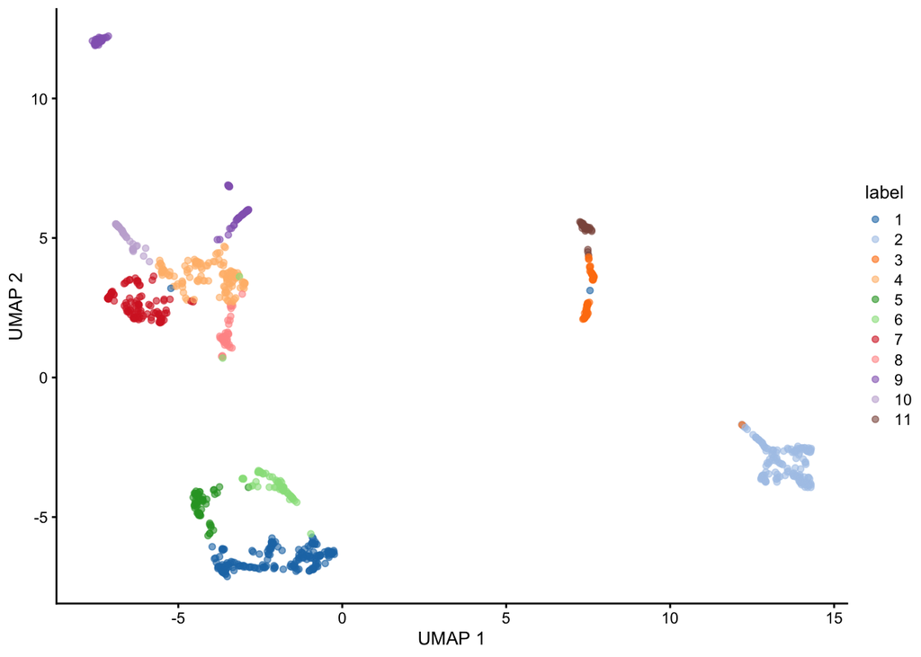

```r
sce <- runUMAP(sce, dimred = "PCA")
plotReducedDim(sce, "UMAP", color_by = "label")
```

# Marker gene detection

To interpret clustering results as obtained in the previous section, we identify the genes that drive separation between clusters. These marker genes allow us to assign biological meaning to each cluster based on their functional annotation. In the simplest case, we have *a priori* knowledge of the marker genes associated with particular cell types, allowing us to treat the clustering as a proxy for cell type identity.

The most straightforward approach to marker gene detection involves testing for differential expression between clusters. If a gene is strongly DE between clusters, it is likely to have driven the separation of cells in the clustering algorithm.

Here, we perform a Wilcoxon rank sum test against a log2 fold change threshold of 1, focusing on up-regulated (positive) markers in one cluster when compared to another cluster.

```r
rownames(sce) <- rowData(sce)$SYMBOL
markers <- findMarkers(sce, test.type = "wilcox", direction = "up", lfc = 1)
markers
```

```
## List of length 11
## names(11): 1 2 3 4 5 6 7 8 9 10 11
```

The resulting object contains a sorted marker gene list for each cluster, in which the top genes are those that contribute the most to the separation of that cluster from mall other clusters.

Here, we inspect the ranked marker gene list for the first cluster.

```r
markers[[1]]
```

```
## DataFrame with 29453 rows and 14 columns
##                  Top     p.value         FDR summary.AUC     AUC.2     AUC.3
##            <integer>   <numeric>   <numeric>   <numeric> <numeric> <numeric>
## Ptn                1 5.19343e-59 1.52962e-54    0.991118  0.991118  0.989549
## Slc2a3             1 3.12952e-19 1.44021e-16    0.781579  0.781579  0.587073
## Zeb2               2 1.11399e-09 3.06638e-07    0.768113  0.487883  0.408097
## Cdca7              2 1.20304e-11 3.69096e-09    0.845176  0.708525  0.592869
## Sox2               2 2.31053e-26 1.54664e-23    0.818395  0.818395  0.821375
## ...              ...         ...         ...         ...       ...       ...
## AC125149.2     29448           1           1           0         0         0
## AC125149.4     29449           1           1           0         0         0
## AC234645.1     29450           1           1           0         0         0
## AC168977.2     29451           1           1           0         0         0
## Vmn2r122       29453           1           1           0         0         0
##                AUC.4     AUC.5     AUC.6     AUC.7     AUC.8     AUC.9
##            <numeric> <numeric> <numeric> <numeric> <numeric> <numeric>
## Ptn         0.926920 0.7912657 0.8560265  0.597150  0.924077  0.964414
## Slc2a3      0.520957 0.0222058 0.0619213  0.804836  0.686687  0.296760
## Zeb2        0.524283 0.3316062 0.7681135  0.383803  0.308555  0.557308
## Cdca7       0.306666 0.0971297 0.2696849  0.346766  0.217088  0.656152
## Sox2        0.794409 0.3086603 0.5134630  0.791259  0.803743  0.818482
## ...              ...       ...       ...       ...       ...       ...
## AC125149.2         0         0         0         0         0         0
## AC125149.4         0         0         0         0         0         0
## AC234645.1         0         0         0         0         0         0
## AC168977.2         0         0         0         0         0         0
## Vmn2r122           0         0         0         0         0         0
##               AUC.10    AUC.11
##            <numeric> <numeric>
## Ptn         0.978164  0.990700
## Slc2a3      0.641253  0.686861
## Zeb2        0.445472  0.205660
## Cdca7       0.845176  0.770958
## Sox2        0.797927  0.818121
## ...              ...       ...
## AC125149.2         0         0
## AC125149.4         0         0
## AC234645.1         0         0
## AC168977.2         0         0
## Vmn2r122           0         0
```

The `Top` field provides the the minimum rank across all pairwise comparisons. The `p.value` field provides the combined *p*-value across all comparisons, and the `FDR` field the BH-adjusted *p*-value for each gene. The `summary.AUC` provides area under the curve (here the concordance probability) from the comparison with the lowest *p*-value, the `AUC.n` fields provide the AUC for each pairwise comparison. The AUC is the probability that a randomly selected cell in cluster *A* has a greater expression of gene *X* than a randomly selected cell in *B*.

We can then inspect the top marker genes for the first cluster using the `plotExpression` function from the scater package.

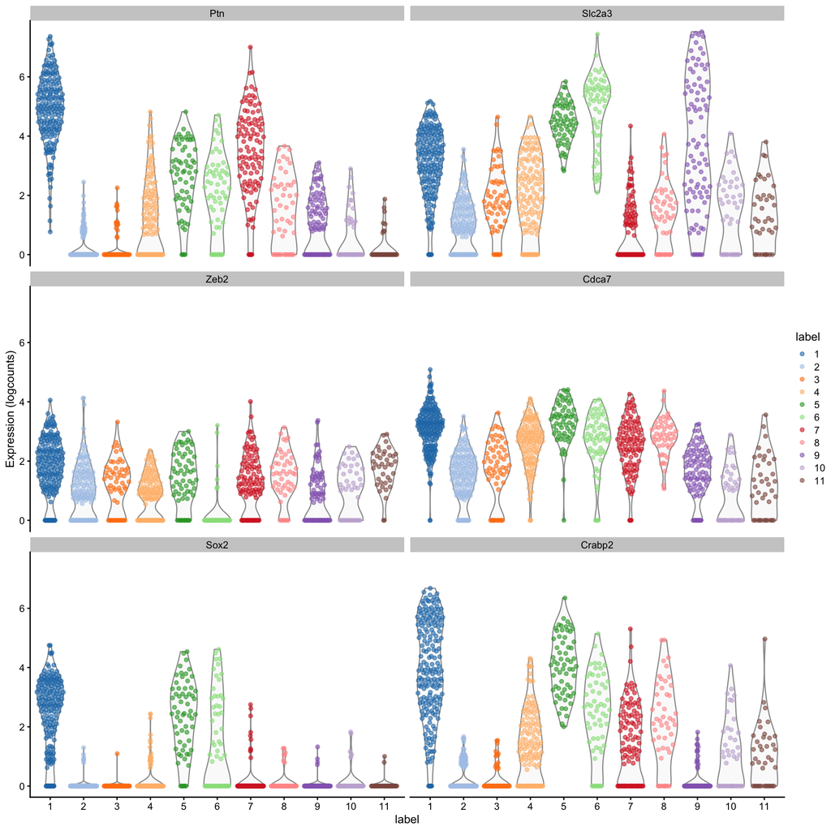

```r
top.markers <- head(rownames(markers[[1]]))
plotExpression(sce, features = top.markers, x = "label", color_by = "label")
```

# Cell type annotation

The most challenging task in scRNA-seq data analysis is arguably the interpretation of the results. Obtaining clusters of cells is fairly straightforward, but it is more difficult to determine what biological state is represented by each of those clusters. Doing so requires us to bridge the gap between the current dataset and prior biological knowledge, and the latter is not always available in a consistent and quantitative manner. Indeed, even the concept of a “cell type” is [not clearly defined](https://doi.org/10.1016/j.cels.2017.03.006), with most practitioners possessing a “I’ll know it when I see it” intuition that is not amenable to computational analysis. As such, interpretation of scRNA-seq data is often manual and a common bottleneck in the analysis workflow.

To expedite this step, we can use various computational approaches that exploit prior information to assign meaning to an uncharacterized scRNA-seq dataset. The most obvious sources of prior information are the curated gene sets associated with particular biological processes, e.g., from the Gene Ontology (GO) or the Kyoto Encyclopedia of Genes and Genomes (KEGG) collections. Alternatively, we can directly compare our expression profiles to published reference datasets where each sample or cell has already been annotated with its putative biological state by domain experts. Here, we will demonstrate both approaches on the wild-type chimera dataset.

## Assigning cell labels from reference data

A conceptually straightforward annotation approach is to compare the single-cell expression profiles with previously annotated reference datasets. Labels can then be assigned to each cell in our uncharacterized test dataset based on the most similar reference sample(s), for some definition of “similar”. This is a standard classification challenge that can be tackled by standard machine learning techniques such as random forests and support vector machines. Any published and labelled RNA-seq dataset (bulk or single-cell) can be used as a reference, though its reliability depends greatly on the expertise of the original authors who assigned the labels in the first place.

In this section, we will demonstrate the use of the *SingleR* method for cell type annotation [Aran et al., 2019](https://www.nature.com/articles/s41590-018-0276-y). This method assigns labels to cells based on the reference samples with the highest Spearman rank correlations, using only the marker genes between pairs of labels to focus on the relevant differences between cell types. It also performs a fine-tuning step for each cell where the correlations are recomputed with just the marker genes for the top-scoring labels. This aims to resolve any ambiguity between those labels by removing noise from irrelevant markers for other labels. Further details can be found in the [*SingleR* book](https://bioconductor.org/books/release/SingleRBook) from which most of the examples here are derived.

```r
ref <- EmbryoAtlasData(samples = 29)
```

```r
ref
```

```
## class: SingleCellExperiment
## dim: 29452 7569
## metadata(0):
## assays(1): counts
## rownames(29452): ENSMUSG00000051951 ENSMUSG00000089699 ...
##   ENSMUSG00000096730 ENSMUSG00000095742
## rowData names(2): ENSEMBL SYMBOL
## colnames(7569): cell_95727 cell_95728 ... cell_103294 cell_103295
## colData names(17): cell barcode ... colour sizeFactor
## reducedDimNames(2): pca.corrected umap
## mainExpName: NULL
## altExpNames(0):
```

```r
table(ref$stage)
```

```
##
## E8.5
## 7569
```

To speed up the computations, we subsample the dataset to 1,000 cells.

```r
set.seed(123)
ind <- sample(ncol(ref), 1000)
ref <- ref[,ind]
```

```r
tab <- sort(table(ref$celltype), decreasing = TRUE)
tab
```

```
##
##   Forebrain/Midbrain/Hindbrain                     Erythroid3
##                            131                             75
##              Paraxial mesoderm                            NMP
##                             69                             51
##                   ExE mesoderm               Surface ectoderm
##                             49                             47
##                      Allantois                     Mesenchyme
##                             46                             45
##                    Spinal cord            Pharyngeal mesoderm
##                             45                             41
##                   ExE endoderm                   Neural crest
##                             38                             35
##                            Gut Haematoendothelial progenitors
##                             30                             27
##          Intermediate mesoderm                 Cardiomyocytes
##                             27                             26
##               Somitic mesoderm                    Endothelium
##                             25                             23
##                     Erythroid2                  Def. endoderm
##                             11                              3
##                     Erythroid1            Blood progenitors 1
##                              2                              1
##            Blood progenitors 2                Caudal Mesoderm
##                              1                              1
##                            PGC
##                              1
```

```r
ref <- logNormCounts(ref)
```

Some cleaning - remove cells of the reference dataset for which the cell type annotation is missing.

```r
nna <- !is.na(ref$celltype)
ref <- ref[,nna]
```

Also remove cell types of very low abundance (here less than 10 cells) to remove noise prior to subsequent annotation tasks.

```r
abu.ct <- names(tab)[tab >= 10]
ind <- ref$celltype %in% abu.ct
ref <- ref[,ind]
```

Restrict to genes shared between query and reference dataset.

```r
rownames(ref) <- rowData(ref)$SYMBOL
isect <- intersect(rownames(sce), rownames(ref))
sce <- sce[isect,]
ref <- ref[isect,]
```

Convert sparse assay matrices to regular dense matrices for input to SingleR.

```r
sce.mat <- as.matrix(assay(sce, "logcounts"))
ref.mat <- as.matrix(assay(ref, "logcounts"))
```

```r
res <- SingleR(test = sce.mat, ref = ref.mat, labels = ref$celltype)
res
```

```
## DataFrame with 1000 rows and 4 columns
##                                    scores                 labels delta.next
##                                  <matrix>            <character>  <numeric>
## cell_11995 0.348586:0.335451:0.314515:... Forebrain/Midbrain/H..  0.1285110
## cell_10294 0.273570:0.260013:0.298932:...             Erythroid3  0.1381951
## cell_9963  0.328538:0.291288:0.475611:...            Endothelium  0.2193295
## cell_11610 0.281161:0.269245:0.299961:...             Erythroid3  0.0359215
## cell_10910 0.422454:0.346897:0.355947:...           ExE mesoderm  0.0984285
## ...                                   ...                    ...        ...
## cell_11597 0.323805:0.292967:0.300485:...                    NMP  0.1663369
## cell_9807  0.464466:0.374189:0.381698:...             Mesenchyme  0.0833019
## cell_10095 0.341721:0.288215:0.485324:...            Endothelium  0.0889931
## cell_11706 0.267487:0.240215:0.286012:...             Erythroid2  0.0350557
## cell_11860 0.345786:0.343437:0.313994:... Forebrain/Midbrain/H..  0.0117001
##                     pruned.labels
##                       <character>
## cell_11995 Forebrain/Midbrain/H..
## cell_10294             Erythroid3
## cell_9963             Endothelium
## cell_11610             Erythroid3
## cell_10910           ExE mesoderm
## ...                           ...
## cell_11597                    NMP
## cell_9807              Mesenchyme
## cell_10095            Endothelium
## cell_11706             Erythroid2
## cell_11860 Forebrain/Midbrain/H..
```

We inspect the results using a heatmap of the per-cell and label scores. Ideally, each cell should exhibit a high score in one label relative to all of the others, indicating that the assignment to that label was unambiguous. This is largely the case for mesenchyme and endothelial cells, whereas we see expectedly more ambiguity between the two erythroid cell populations.

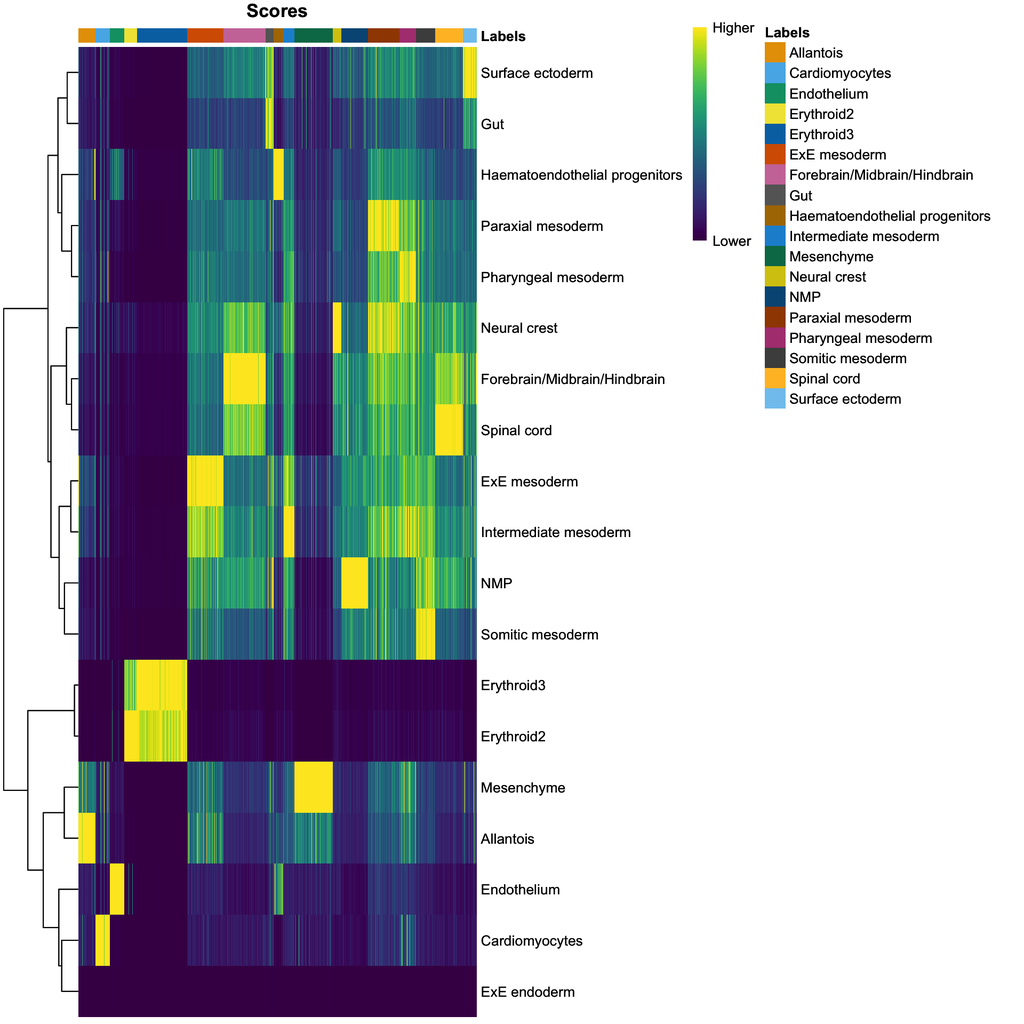

```r
plotScoreHeatmap(res)
```

We also compare the cell type assignments with the clustering results to determine the identity of each cluster. Here, several cell type classes are nested within the same cluster, indicating that these clusters are composed of several transcriptomically similar cell populations (such as cluster 4 and 6). On the other hand, there are also instances where we have several clusters for the same cell type, indicating that the clustering represents finer subdivisions within these cell types.

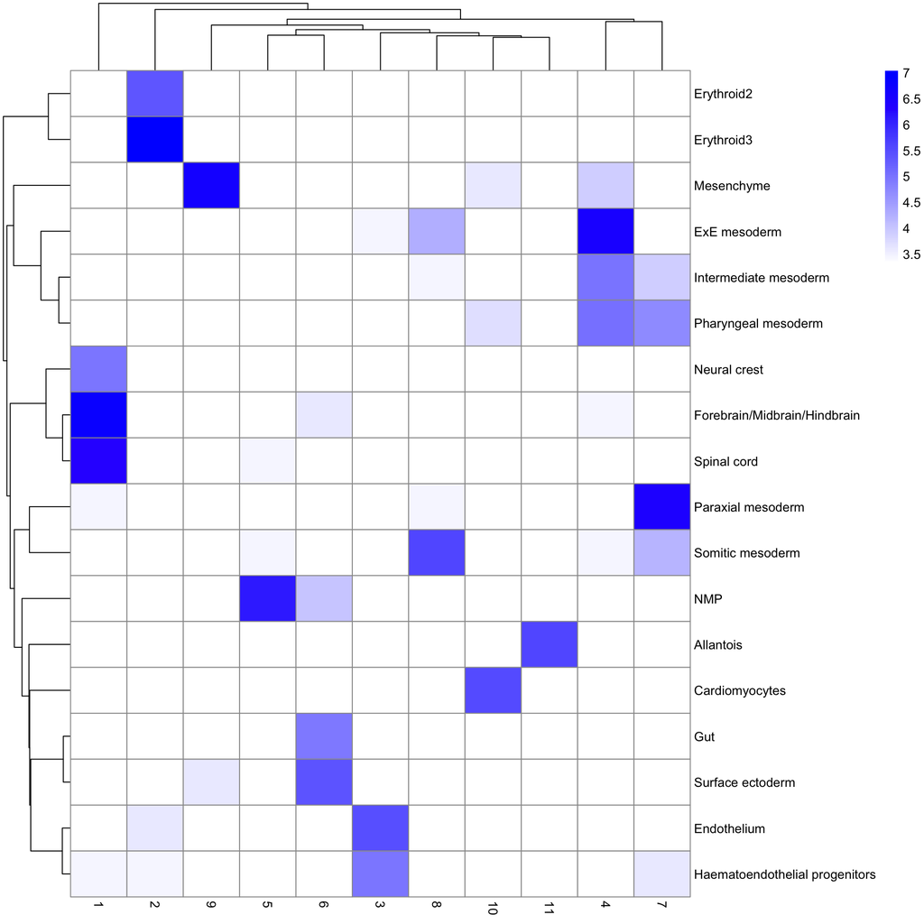

```r
library(pheatmap)
tab <- table(anno = res$pruned.labels, cluster = colLabels(sce))
pheatmap(log2(tab + 10), color = colorRampPalette(c("white", "blue"))(101))
```

As it so happens, we are in the fortunate position where our test dataset also contains independently defined labels. We see strong consistency between the two sets of labels, indicating that our automatic annotation is comparable to that generated manually by domain experts.

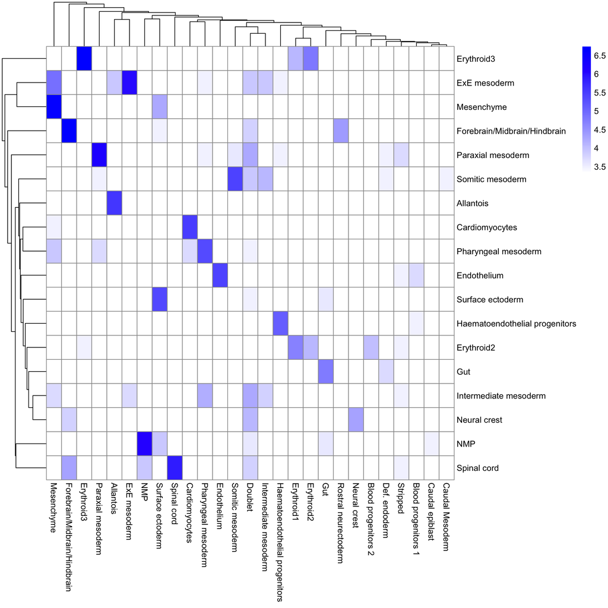

```r
tab <- table(res$pruned.labels, sce$celltype.mapped)
pheatmap(log2(tab + 10), color = colorRampPalette(c("white", "blue"))(101))
```

## Assigning cell labels from gene sets

A related strategy is to explicitly identify sets of marker genes that are highly expressed in each individual cell. This does not require matching of individual cells to the expression values of the reference dataset, which is faster and more convenient when only the identities of the markers are available. We demonstrate this approach using cell type markers derived from the mouse embryo atlas dataset.

```r
library(scran)
wilcox.z <- pairwiseWilcox(ref, ref$celltype, lfc = 1, direction = "up")
```

```r
markers.z <- getTopMarkers(wilcox.z$statistics, wilcox.z$pairs,
                           pairwise = FALSE, n = 50)
lengths(markers.z)
```

```
##                      Allantois                 Cardiomyocytes
##                            106                            106
##                    Endothelium                     Erythroid2
##                            103                             54
##                     Erythroid3                   ExE endoderm
##                             84                            102
##                   ExE mesoderm   Forebrain/Midbrain/Hindbrain
##                             97                             97
##                            Gut Haematoendothelial progenitors
##                             90                             71
##          Intermediate mesoderm                     Mesenchyme
##                             70                            118
##                   Neural crest                            NMP
##                             66                             91
##              Paraxial mesoderm            Pharyngeal mesoderm
##                             88                             85
##               Somitic mesoderm                    Spinal cord
##                             86                             91
##               Surface ectoderm
##                             92
```

Our test dataset will be as before the wild-type chimera dataset.

```r
sce
```

```
## class: SingleCellExperiment
## dim: 29411 1000
## metadata(0):
## assays(2): counts logcounts
## rownames(29411): Xkr4 Gm1992 ... Vmn2r122 CAAA01147332.1
## rowData names(2): ENSEMBL SYMBOL
## colnames(1000): cell_11995 cell_10294 ... cell_11706 cell_11860
## colData names(12): cell barcode ... sizeFactor label
## reducedDimNames(4): pca.corrected.E7.5 pca.corrected.E8.5 PCA UMAP
## mainExpName: NULL
## altExpNames(0):
```

We use the *AUCell* package to identify marker sets that are highly expressed in each cell. This method ranks genes by their expression values within each cell and constructs a response curve of the number of genes from each marker set that are present with increasing rank. It then computes the area under the curve (AUC) for each marker set, quantifying the enrichment of those markers among the most highly expressed genes in that cell. This is roughly similar to performing a Wilcoxon rank sum test between genes in and outside of the set, but involving only the top ranking genes by expression in each cell.

```r
library(GSEABase)
all.sets <- lapply(names(markers.z),
                   function(x) GeneSet(markers.z[[x]], setName = x))
all.sets <- GeneSetCollection(all.sets)
all.sets
```

```
## GeneSetCollection
##   names: Allantois, Cardiomyocytes, ..., Surface ectoderm (19 total)
##   unique identifiers: Prrx2, Spin2c, ..., Igf2bp3 (560 total)
##   types in collection:
##     geneIdType: NullIdentifier (1 total)
##     collectionType: NullCollection (1 total)
```

```r
library(AUCell)
rankings <- AUCell_buildRankings(as.matrix(counts(sce)),
                                 plotStats = FALSE, verbose = FALSE)
cell.aucs <- AUCell_calcAUC(all.sets, rankings)
results <- t(assay(cell.aucs))
head(results)
```

```
##             gene sets
## cells         Allantois Cardiomyocytes Endothelium Erythroid2 Erythroid3
##   cell_11995 0.21994609      0.2336827   0.1947563 0.12228508  0.1639749
##   cell_10294 0.10066221      0.1246414   0.1104634 0.60732017  0.6081721
##   cell_9963  0.34273069      0.3158431   0.5407815 0.13588372  0.1797007
##   cell_11610 0.08244651      0.1340388   0.1048735 0.57892981  0.5706619
##   cell_10910 0.31763336      0.2784001   0.2445795 0.08175859  0.1354818
##   cell_11021 0.20549732      0.2320122   0.1869839 0.11351012  0.1769588
##             gene sets
## cells        ExE endoderm ExE mesoderm Forebrain/Midbrain/Hindbrain       Gut
##   cell_11995   0.06053637    0.4371076                    0.6319109 0.3779960
##   cell_10294   0.06369959    0.1900184                    0.2670988 0.1482988
##   cell_9963    0.09466189    0.4165978                    0.4972886 0.3805059
##   cell_11610   0.05720738    0.2060333                    0.2785028 0.1466698
##   cell_10910   0.11787498    0.5770948                    0.5721069 0.4450836
##   cell_11021   0.09285926    0.4736976                    0.6011933 0.3993608
##             gene sets
## cells        Haematoendothelial progenitors Intermediate mesoderm Mesenchyme
##   cell_11995                      0.3329538             0.5396029  0.2456757
##   cell_10294                      0.1621829             0.1781659  0.1078670
##   cell_9963                       0.6010306             0.4623277  0.3566887
##   cell_11610                      0.1526329             0.1968055  0.1118536
##   cell_10910                      0.4333710             0.5481614  0.3512731
##   cell_11021                      0.3336212             0.5197592  0.2403682
##             gene sets
## cells        Neural crest       NMP Paraxial mesoderm Pharyngeal mesoderm
##   cell_11995    0.6535231 0.4841026         0.5510547           0.5076289
##   cell_10294    0.2840264 0.2113283         0.2192031           0.2049349
##   cell_9963     0.5374756 0.3740042         0.5007010           0.4618718
##   cell_11610    0.2949987 0.2235049         0.2348724           0.2134701
##   cell_10910    0.5472885 0.5225294         0.5506325           0.5564014
##   cell_11021    0.5863399 0.5731637         0.4992671           0.4707530
##             gene sets
## cells        Somitic mesoderm Spinal cord Surface ectoderm
##   cell_11995        0.4654095   0.5807133        0.5251957
##   cell_10294        0.2141816   0.2290110        0.1874113
##   cell_9963         0.4307335   0.4373858        0.4173470
##   cell_11610        0.2339673   0.2564642        0.2054802
##   cell_10910        0.5179489   0.5167149        0.5049140
##   cell_11021        0.5186006   0.5526277        0.5052879
```

We assign cell type identity to each cell in the test dataset by taking the marker set with the top AUC as the label for that cell. Our new labels mostly agree with the original annotation (and, thus, also with the reference-based annotation). Instances where the original annotation is divided into several new label groups typically points to large overlaps in their marker sets. In the absence of prior annotation, a more general diagnostic check is to compare the assigned labels to cluster identities, under the expectation that most cells of a single cluster would have the same label (or, if multiple labels are present, they should at least represent closely related cell states).

```r
new.labels <- colnames(results)[max.col(results)]
tab <- table(new.labels, sce$celltype.mapped)
tab
```

```
##
## new.labels                       Allantois Blood progenitors 1
##   Allantois                             28                   0
##   Cardiomyocytes                         0                   0
##   Endothelium                            0                   0
##   Erythroid2                             0                   0
##   Erythroid3                             0                   0
##   ExE mesoderm                           0                   0
##   Forebrain/Midbrain/Hindbrain           1                   0
##   Gut                                    0                   0
##   Haematoendothelial progenitors         1                   0
##   Intermediate mesoderm                  0                   0
##   Mesenchyme                             0                   0
##   Neural crest                          11                   4
##   NMP                                    0                   0
##   Paraxial mesoderm                      5                   0
##   Pharyngeal mesoderm                    0                   0
##   Somitic mesoderm                       0                   0
##   Spinal cord                            0                   0
##   Surface ectoderm                       0                   0
##
## new.labels                       Blood progenitors 2 Cardiomyocytes
##   Allantois                                        0              0
##   Cardiomyocytes                                   0             27
##   Endothelium                                      0              0
##   Erythroid2                                       1              0
##   Erythroid3                                       0              0
##   ExE mesoderm                                     0              0
##   Forebrain/Midbrain/Hindbrain                     0              0
##   Gut                                              0              0
##   Haematoendothelial progenitors                   0              0
##   Intermediate mesoderm                            0              0
##   Mesenchyme                                       0              0
##   Neural crest                                     6              1
##   NMP                                              0              0
##   Paraxial mesoderm                                0              4
##   Pharyngeal mesoderm                              0              6
##   Somitic mesoderm                                 0              0
##   Spinal cord                                      0              0
##   Surface ectoderm                                 0              0
```

[output cut: 165 more lines]

```
##   Erythroid2                               0        1                0
##   Erythroid3                               0        1                0
##   ExE mesoderm                             0        0                0
##   Forebrain/Midbrain/Hindbrain            37        0               17
##   Gut                                      0        0                2
##   Haematoendothelial progenitors           0        0                0
##   Intermediate mesoderm                    0        0                0
##   Mesenchyme                               0        0                2
##   Neural crest                             3        5                6
##   NMP                                      0        0                0
##   Paraxial mesoderm                        0        0                0
##   Pharyngeal mesoderm                      0        0                0
##   Somitic mesoderm                         0        0                0
##   Spinal cord                              9        0                0
##   Surface ectoderm                         0        0               20
```

As a diagnostic measure, we examine the distribution of AUCs across cells for each label. In heterogeneous populations, the distribution for each label should be bimodal with one high-scoring peak containing cells of that cell type and a low-scoring peak containing cells of other types. The gap between these two peaks can be used to derive a threshold for whether a label is “active” for a particular cell. (In this case, we simply take the single highest-scoring label per cell as the labels should be mutually exclusive.) In populations where a particular cell type is expected, lack of clear bimodality for the corresponding label may indicate that its gene set is not sufficiently informative.

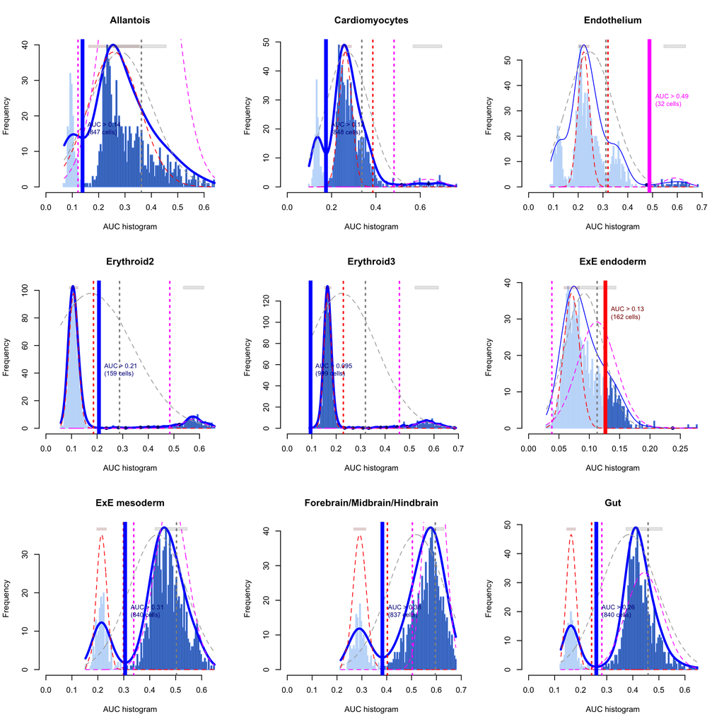

```r
par(mfrow = c(3,3))
AUCell_exploreThresholds(cell.aucs[1:9], plotHist = TRUE, assign = TRUE)
```

Shown is the distribution of AUCs in the wild-type chimera dataset for each label in the embryo atlas dataset. The blue curve represents the density estimate, the red curve represents a fitted two-component mixture of normals, the pink curve represents a fitted three-component mixture, and the grey curve represents a fitted normal distribution. Vertical lines represent threshold estimates corresponding to each estimate of the distribution.

# Further Reading

- OSCA book, [Chapters 5-7](https://bioconductor.org/books/release/OSCA.basic/clustering.html)
- Assigning cell types with SingleR ([the book](https://bioconductor.org/books/release/SingleRBook/)).
- The AUCell package vignette.

# Exercises

1. Clustering: The [Leiden algorithm](https://www.nature.com/articles/s41598-019-41695-z) is similar to the Louvain algorithm, but it is faster and has been shown to result in better connected communities. Modify the above call to `clusterCells` to carry out the community detection with the Leiden algorithm instead. Visualize the results in a UMAP plot.

Hint: The `NNGraphParam` constructor has an argument `cluster.args`. This allows to specify arguments passed on to the `cluster_leiden` function from the [igraph](https://cran.r-project.org/web/packages/igraph/index.html) package. Use the `cluster.args` argument to parameterize the clustering to use modularity as the objective function and a resolution parameter of 0.5.

2. Cluster annotation: Another strategy for annotating the clusters is to perform a gene set enrichment analysis on the marker genes defining each cluster. This identifies the pathways and processes that are (relatively) active in each cluster based on upregulation of the associated genes compared to other clusters. Focus on the top 100 up-regulated genes in a cluster of your choice and perform a gene set enrichment analysis of biological process (BP) gene sets from the Gene Ontology (GO).

Hint: Use the `goana()` function from the *limma* package to identify GO BP terms that are overrepresented in the list of marker genes.

3. Workflow: The scRNAseq package provides gene-level counts for a collection of public scRNA-seq datasets, stored as `SingleCellExperiment` objects with annotated cell- and gene-level metadata. Consult the vignette of the scRNAseq package to inspect all available datasets and select a dataset of your choice. Perform a typical scRNA-seq analysis on this dataset including QC, normalization, feature selection, dimensionality reduction, clustering, and marker gene detection.